# Final

Tyler Poelking

4/21/2018

```r
set.seed(23422432)
library(rjags)
```

```r
library(boot)
library(ggplot2)
library(grid)
library(gridExtra)
library(reshape2)
library(plyr)
library(dplyr)
fluData <- read.table( "~/Desktop/All Stuff/School Stuff/STATS/3303/final/flu.txt", header=T )
attach(fluData)

nTotal <- length(Infected)
nC <- length(unique(Country))
countryNumeric = as.numeric(Country)
```

```r
# create objects for JAGS
dataList <- list( "Infected" = Infected,
                  "EZK" = EZK,
                  "country" = countryNumeric,
                  "nC" = nC,
                  "nTotal" = nTotal)

# list of parameters to be monitored
parameters <- c(
                 "alpha",
                 "beta",
                 "mu_alpha",
                 "mu_beta",
                 "sigma2_alpha",
                 "sigma2_beta",
                 "theta")

# set initial values
initsValues <- list(
                    "alpha" = rep(0, nC),
                     "beta" = rep(0, nC),
                    "mu_alpha" = 0,
                     "mu_beta" = 0,
                     "sigma2_alpha" = 1,
                     "sigma2_beta" = 1)

# number of iteration for "tuning"
adaptSteps <- 5000

# number of iterations for "burn-in"
burnInSteps <- 5000

# number of chains to run
nChains <- 2

# total number of iterations to save
numSavedSteps <- 5000

# "thinning" (1 = keep every interation)
thinSteps <- 1

# iterations per chain
ITER <- ceiling( (numSavedSteps * thinSteps) / nChains )

# -------------
# Run JAGS
# -------------

# create, initialize, and adapt the model
jagsModel <- jags.model( "finalModel.txt",
                         data = dataList,
                         inits = initsValues,
                         n.chains = nChains,
                         n.adapt = adaptSteps )
```

```r
# burn-in the algorithm
update( jagsModel,
        n.iter = burnInSteps )

# run algorithm to get interations for inference
codaSamples <- coda.samples( jagsModel,
                             variable.names = parameters,
                             n.iter = ITER,
                             thin = thinSteps )

# -------------
# Look at posterior samples
# -------------

# make a dataframe with the posterior samples
mcmcChainDF <- data.frame( as.matrix( codaSamples,
                                      iters = T,
                                      chains = T ) )

# create a vector with the variable names
varNames <- names( mcmcChainDF )[3:( 26 )]

# number of variables
nVars <- length( varNames )

mcmcChainDF$CHAIN <- as.factor(mcmcChainDF$CHAIN)

# construct trace plots
p <- list()
for( k in 1:nVars )
{
  plot_frame <- mcmcChainDF
  plot_frame$dep_var <- mcmcChainDF[ , varNames[k]]
  p[[k]] <- ggplot( plot_frame,
                    aes( x = ITER,
                         y = dep_var))  +
    geom_line( aes( color = CHAIN ) ) +
    labs( y = varNames[k] )
}
```

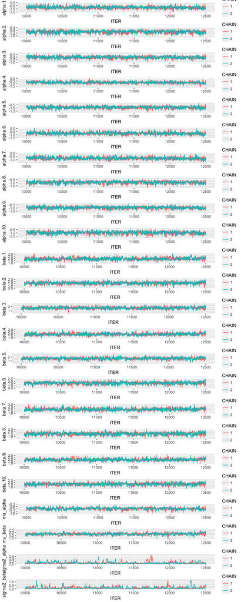

```r
do.call( grid.arrange, c( p, list("ncol" = 1) ) )
```

The initial values are:

alpha = 0 for all 10 countries beta = 0 for all 10 countries mu_alpha = 0 mu_beta = 0 sigma2_alpha = 1 sigma2_beta = 1

The number of iterations for tuning and burn-in were set to 5000. Two chains ran for an additional 2,500 iterations each. The trace plots above show both chains appear to be sampling from the same distributions and are evenly bouncing around a centralized value with all apparent patterns repeating, thus providing evidence the algorithm converged.

Conditional Dependence: In this model, we assume that if we know both the probability of infection of an individual at a particular country, the responses are independent.

We know the probability of infeciton of an individual at a particular country through the particular country’s log odds that a subject whose EZK test was negative is infected, the particular country’s difference in log offs of a subjet who scored positive on the EZK test’s showing as infected relative to subjects who scored negative, and the individual’s EZK test score.

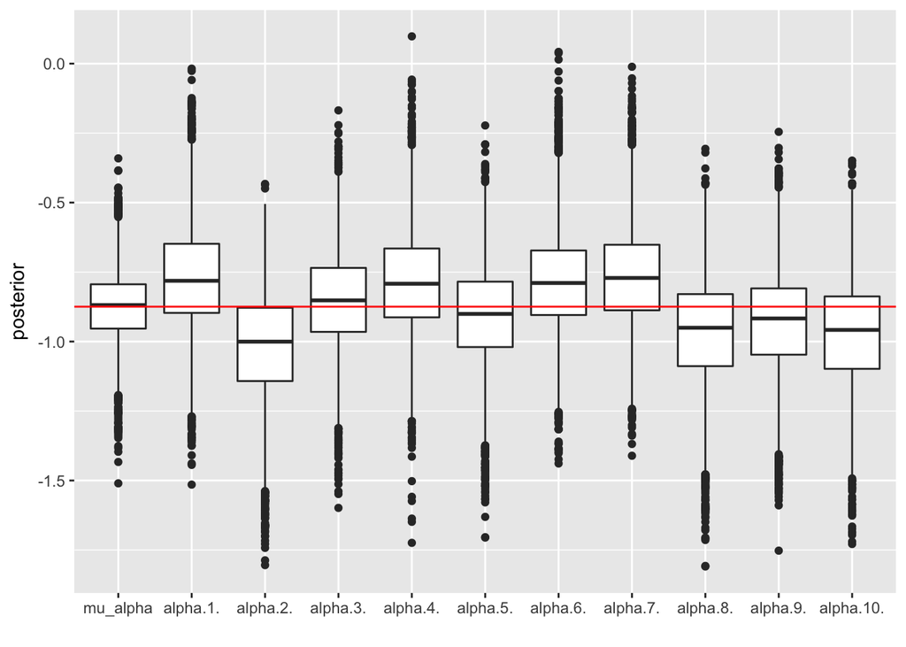

```r
#boxplot of alphas and intercept
alphaPostDFreshape <- melt( mcmcChainDF,
                       id.vars = "ITER",
                       measure.vars = c("mu_alpha",
                                        "alpha.1.",
                                        "alpha.2.",
                                        "alpha.3.",
                                        "alpha.4.",
                                        "alpha.5.",
                                        "alpha.6.",
                                        "alpha.7.",
                                        "alpha.8.",
                                        "alpha.9.",
                                        "alpha.10."))
ggplot(alphaPostDFreshape,
       aes(x = variable, y = value )) +
  geom_boxplot() +
  ylab( "posterior" ) +
  xlab( "" ) + geom_hline(yintercept = mean(mcmcChainDF$mu_alpha), color = 'red')
```

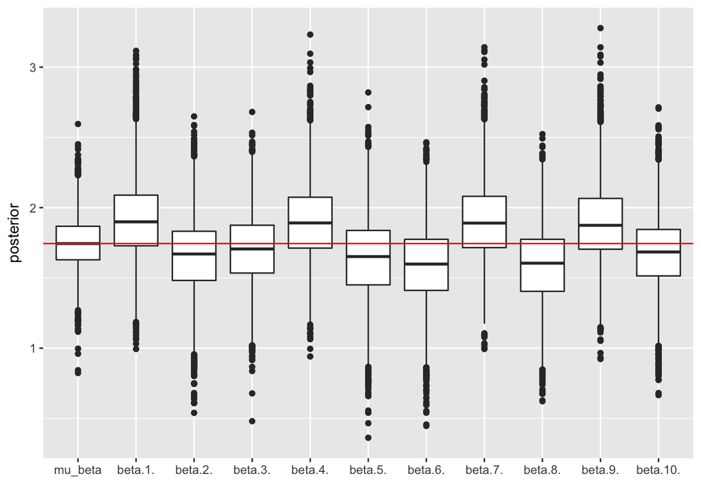

```r
#boxplot of betas
betaPostDFreshape <- melt( mcmcChainDF,
                       id.vars = "ITER",
                       measure.vars = c("mu_beta",
                                        "beta.1.",
                                        "beta.2.",
                                        "beta.3.",
                                        "beta.4.",
                                        "beta.5.",
                                        "beta.6.",
                                        "beta.7.",
                                        "beta.8.",
                                        "beta.9.",
                                        "beta.10."))
ggplot(betaPostDFreshape,
       aes(x = variable, y = value )) +
  geom_boxplot() +
  ylab( "posterior" ) +
  xlab( "" )+ geom_hline(yintercept =  mean(mcmcChainDF$mu_beta), color = 'red')
```

*Note: When referring to a patient as being infected or not infected, we refer to the infected status derived from the highly accurate diagnositc test.

The alphas capture the country-specific change in log odds that a subject whose EZK test is negative is infected. As a country’s alpha increases, the likelihood of a subject who scored negative on the EKZ test actually having influenza increases.

```r
#Get alpha based on entire data
numer = fluData %>% filter(Infected ==1 & EZK ==0)
denom = fluData %>% filter(EZK==0)
logit(length(numer[[1]])/length(denom[[1]]))
```

```
## [1] -0.8688242
```

```r
inv.logit(mean(mcmcChainDF$mu_alpha))
```

```
## [1] 0.2943143
```

```r
#iterate through countries and get their true 'alpha '
for (c in c("A", "B", "C","D", "E", "F", "G", "H","I", "J")){
    country = subset(fluData, Country == c)
    country_num <- country %>%
          filter(EZK ==0 & Infected ==1)
    country_den <- country %>%
          filter(EZK==0)
    print(length(country_num[[1]])/length(country_den[[1]]))

}
```

```
## [1] 0.3255814
## [1] 0.2280702
## [1] 0.3269231
## [1] 0.3170732
## [1] 0.296875
## [1] 0.3958333
## [1] 0.3269231
## [1] 0.2745098
## [1] 0.2363636
## [1] 0.25
```

```r
#Find corresponding values for each country to compare
print("Country's estimated inv.logit(alpha) based on model: ")
```

```
## [1] "Country's estimated inv.logit(alpha) based on model: "
```

```r
cat("Country A: ",inv.logit(mean(mcmcChainDF$alpha.1.)))
```

```
## Country A:  0.3164124
```

```r
cat("Country B: ",inv.logit(mean(mcmcChainDF$alpha.2.)))
```

```
## Country B:  0.2649588
```

```r
cat("Country C: ",inv.logit(mean(mcmcChainDF$alpha.3.)))
```

```
## Country C:  0.2989265
```

```r
cat("Country D: ",inv.logit(mean(mcmcChainDF$alpha.4.)))
```

```
## Country D:  0.3134526
```

```r
cat("Country E: ",inv.logit(mean(mcmcChainDF$alpha.5.)))
```

```
## Country E:  0.2873533
```

```r
cat("Country F: ",inv.logit(mean(mcmcChainDF$alpha.6.)))
```

```
## Country F:  0.3143017
```

```r
cat("Country G: ",inv.logit(mean(mcmcChainDF$alpha.7.)))
```

```
## Country G:  0.3178865
```

```r
cat("Country H: ",inv.logit(mean(mcmcChainDF$alpha.8.)))
```

```
## Country H:  0.2755503
```

```r
cat("Country I: ",inv.logit(mean(mcmcChainDF$alpha.9.)))
```

```
## Country I:  0.2828138
```

```r
cat("Country J: ",inv.logit(mean(mcmcChainDF$alpha.10.)))
```

```
## Country J:  0.2742743
```

The betas capture the country-specific change in log odds that a subject whose EZK test is positive is infected, relative to the subject whose EZK test is negative. Adding a country specific’s alpha and beta together derives the country specific log odds that, given the subject scored positive on the EZK test, the subject is infected.

```r
#For entire data
with_infl = length(subset(fluData, EZK == 1)[[1]])
with_infl_and_ezk_positive = length(subset(fluData, Infected == 1 & EZK ==1)[[1]])
pos_ezk_success_rate = with_infl_and_ezk_positive/with_infl
pos_ezk_success_rate
```

```
## [1] 0.7034765
```

```r
inv.logit(mean(mcmcChainDF$mu_alpha) + mean(mcmcChainDF$mu_beta))
```

```
## [1] 0.7047605
```

```r
#iterate through countries and get their true 'alpha + beta'
for (c in c("A", "B", "C","D", "E", "F", "G", "H","I", "J")){
    #subset country A. Based on data
    country = subset(fluData, Country == c)
    country_with_infl = length(subset(country, EZK == 1)[[1]])
    country_with_infl_and_ezk_positive = length(subset(country, Infected == 1 & EZK ==1)[[1]])
    country_success_rate = country_with_infl_and_ezk_positive/country_with_infl
    print(country_success_rate)
}
```

```
## [1] 0.7894737
## [1] 0.627907
## [1] 0.6875
## [1] 0.779661
## [1] 0.6388889
## [1] 0.6538462
## [1] 0.7916667
## [1] 0.6122449
## [1] 0.7555556
## [1] 0.6538462
```

```r
#Find corresponding values for each country to compare
print("Country's estimated inv.logit(alpha+beta) based on model: ")
```

```
## [1] "Country's estimated inv.logit(alpha+beta) based on model: "
```

```r
cat("Country A: ", inv.logit(mean(mcmcChainDF$alpha.1.) + mean(mcmcChainDF$beta.1.)))
```

```
## Country A:  0.7588442
```

```r
cat("Country B: ", inv.logit(mean(mcmcChainDF$alpha.2.) + mean(mcmcChainDF$beta.2.)))
```

```
## Country B:  0.653308
```

```r
cat("Country C: ",inv.logit(mean(mcmcChainDF$alpha.3.) + mean(mcmcChainDF$beta.3.)))
```

```
## Country C:  0.7004353
```

```r
cat("Country D: ",inv.logit(mean(mcmcChainDF$alpha.4.) + mean(mcmcChainDF$beta.4.)))
```

```
## Country D:  0.7529947
```

```r
cat("Country E: ",inv.logit(mean(mcmcChainDF$alpha.5.) + mean(mcmcChainDF$beta.5.)))
```

```
## Country E:  0.6745021
```

```r
cat("Country F: ",inv.logit(mean(mcmcChainDF$alpha.6.) + mean(mcmcChainDF$beta.6.)))
```

```
## Country F:  0.6903979
```

```r
cat("Country G: ",inv.logit(mean(mcmcChainDF$alpha.7.) + mean(mcmcChainDF$beta.7.)))
```

```
## Country G:  0.7587628
```

```r
cat("Country H: ",inv.logit(mean(mcmcChainDF$alpha.8.) + mean(mcmcChainDF$beta.8.)))
```

```
## Country H:  0.6493859
```

```r
cat("Country I: ",inv.logit(mean(mcmcChainDF$alpha.9.) + mean(mcmcChainDF$beta.9.)))
```

```
## Country I:  0.723492
```